# 6.5 An introduction to Shiny

A **Shiny app** is an interactive web application built with R. The user interface appears in a web browser, while an R session receives the inputs, performs the calculations, and returns updated figures, tables, text, or other output. During development, that R session runs on your computer. A deployed app typically runs R on a server that readers access through a web page.

Shiny is useful when we want a reader to explore how results change without editing or running the underlying code. The analyst defines the controls, the values they accept, and the calculations that respond to them. The reader interacts only with the choices provided through the app.

In this lesson, we will build an app that maps the ground above a selected elevation and reports its area. The example is intentionally focused so that we can examine how the user interface, server, and reactive expressions connect. These components provide the foundation for the more complex applications introduced later in the course.

In completing this lesson, you will learn how to:

- Describe the two halves of a Shiny app and what passes between them
- Build an app that draws a raster and lets a reader change what it shows
- Explain what makes an expression reactive, and where the data should be read
- Run an app, and describe what deployment requires

**Important!** Before starting this tutorial, be sure that you have completed all preliminary and previous lessons!

## Data for this lesson

In this lesson, we will explore:

**`scbi_dem.tif`**: Digital elevation model (raster) of the Smithsonian Conservation Biology Institute campus and the land around it, subset from a Virginia state elevation model. The file is in EPSG 4269, with cells of about three meters, and contains elevations in meters.

## Set up your session

Please complete the following to ensure that you are working in a clean session:

1. Please ensure that your **Global Environment** is empty.
2. In the *History* tab of your **workspace pane**, ensure that your **session history** is empty.

This lesson introduces the package *shiny*:

```r
install.packages("shiny")
```

Now that we are working in a clean session:

1. Create a script file.
2. Save your script file as `app.R` in the root of your project, the folder that contains `data` and `scripts`.
3. Add metadata as a comment at the top of the file.
4. Following your metadata, create a new **code section** and call it “`setup`”.
5. Following your section header, attach *shiny*, *tidyterra*, and the packages that comprise the **core tidyverse**.

When an app runs, its working directory is the folder that contains `app.R`. Saving the file at the root of the project means that paths such as `data/raw/gis_scbi/scbi_dem.tif` work in the app exactly as they do in your other scripts. Because the file is named `app.R`, RStudio displays a *Run App* button above it.

Read and preprocess the data in the setup section as well. The elevation model is fixed: it is the same for every browser session, and it does not change while the app runs. We will also calculate the area of each cell because the app will report the area above the selected elevation.

At this point, your script should look something like:

```r
# My code for the introduction to Shiny tutorial

# setup --------------------------------------------------------

library(shiny)
library(tidyterra)
library(tidyverse)

# Elevation model in UTM zone 17N:

dem <-
  terra::rast("data/raw/gis_scbi/scbi_dem.tif") %>%
  terra::project("EPSG:26917") %>%
  rename(elevation = 1)

# Cell area in hectares:

cell_area <-
  dem %>%
  terra::cellSize(
    unit = "ha",
    transform = FALSE
  )
```

The projection follows *6.3 Changing the grid: Resolution, extent and projection*. The file uses the NAD83 datum, so we retain it in the projected CRS. The projected CRS uses meters, and `transform = FALSE` calculates planar cell area from those units.

Code in the setup section runs once, when the app starts. The server function body runs once for each browser session. Reactive and rendering expressions within the server re-evaluate when their dependencies change.

## Shiny user interfaces and servers

A single-file Shiny app contains a user interface, a server function, and a call to `shinyApp()` that combines them.

The **user interface**, usually assigned to `ui`, defines the controls and output locations displayed in the browser. It is a nested set of function calls that Shiny converts to HTML. Each control has an `inputId` that names the value available to the server.

The **server** is a function of `input`, `output`, and `session`. Values from interface controls are available through `input`, and the server assigns rendered results to `output`.

`shinyApp()` combines the user interface and server and runs the app.

The user interface and server use the same names. A control with `inputId = "cutoff"` is available to the server as `input$cutoff`. A plot assigned to `output$map` appears at `plotOutput("map")` in the user interface. These names must match for the server result to appear in the browser.

Below the setup section, write the smallest app that has an interface, a server, and the call that runs them:

```r
ui <- fluidPage()

server <-
  function(
    input,
    output,
    session
  ) {}

shinyApp(ui, server)
```

Click *Run App*. The page that opens is blank, and the *Console* reports the address the app is listening on. This is a working app: the call to `fluidPage()` created an empty page, and the server function body is empty. We will build it up a piece at a time, running it as we go.

### The user interface

The reader sees what we pass to `fluidPage()`, and we add those arguments in turn.

`titlePanel()` puts a heading at the top of the page:

```r
ui <-
  fluidPage(
    titlePanel("Elevation at SCBI")
  )
```

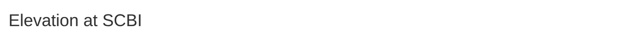

`sidebarLayout()` divides the page: `sidebarPanel()` contains the controls on the left, and `mainPanel()` contains the results on the right. Both are empty for now, so the page shows the grey box of the sidebar and nothing else:

```r
ui <-
  fluidPage(
    titlePanel("Elevation at SCBI"),
    sidebarLayout(
      sidebarPanel(),
      mainPanel()
    )
  )
```

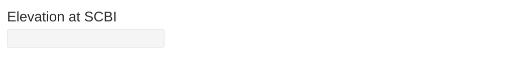

The interface uses `sliderInput()` to add the control that the reader moves. `inputId` names the value that the control produces, `label` is the text displayed above it, `min` and `max` define the range it covers, and `value` sets the position it starts in:

```r
ui <-
  fluidPage(
    titlePanel("Elevation at SCBI"),
    sidebarLayout(
      sidebarPanel(
        sliderInput(
          inputId = "cutoff",
          label = "Show ground above (meters):",
          min = 224,
          max = 392,
          value = 300
        )
      ),
      mainPanel()
    )
  )
```

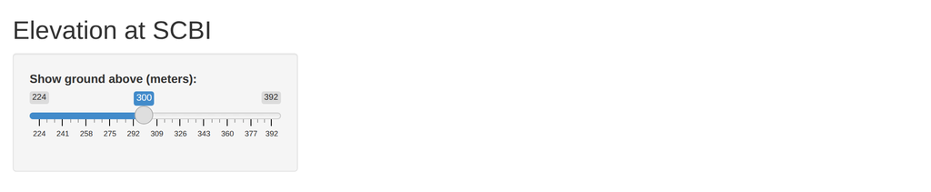

The slider moves, and nothing else happens, because no part of the app reads `input$cutoff` yet.

The `min` and `max` span the range of the raster, rounded outward. Rounding inward would prevent the slider from reaching the lowest or highest elevations. These fixed limits are appropriate because this app always uses the same raster. An app that accepts other elevation data should derive the limits with `global()`.

`plotOutput()` defines the location and name of a plot in the interface:

```r
      mainPanel(
        plotOutput("map")
      )
```

`textOutput()` defines the location and name of a line of text in the same way:

```r
      mainPanel(
        plotOutput("map"),
        textOutput("area")
      )
```

Run the app again and the page looks exactly as it did with the slider alone. The output functions define locations in the interface, but the server has not yet assigned results to them.

Here is the complete interface:

```r
ui <-
  fluidPage(
    titlePanel("Elevation at SCBI"),
    sidebarLayout(
      sidebarPanel(
        sliderInput(
          inputId = "cutoff",
          label = "Show ground above (meters):",
          min = 224,
          max = 392,
          value = 300
        )
      ),
      mainPanel(
        plotOutput("map"),
        textOutput("area")
      )
    )
  )
```

### The server

The server is the function we left empty. We will assign a result to each output name defined in the interface.

`renderPlot()` builds a plot, which we assign to `output$map`. This name matches `plotOutput("map")` in the interface. Inside it, we draw the ground above the cutoff. `input$cutoff` returns the current position of the slider, and `filter()` on a `SpatRaster` sets cells at or below it to `NA`:

```r
server <-
  function(
    input,
    output,
    session
  ) {
    output$map <-
      renderPlot({
        ggplot() +

          # Add geometries:

          geom_spatraster(
            data =
              dem %>%
              filter(elevation > input$cutoff)
          ) +

          # Define scale elements:

          scale_fill_hypso_c(na.value = "grey90") +

          # Modify the theme:

          theme_void()
      })
  }
```

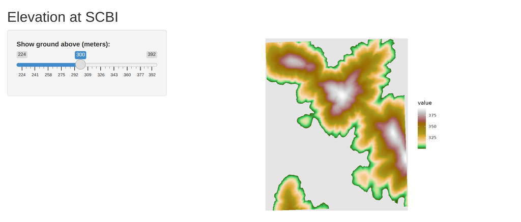

Moving the slider now redraws the map.

**Note**

Recall from *6.1 Introduction to rasters with terra* that `filter()` on a `SpatRaster` sets cells that do not meet the condition to `NA` rather than removing them. The raster extent therefore remains unchanged as the slider moves, so the map does not jump around. The argument `na.value = "grey90"` draws the excluded ground.

`renderText()` builds the sentence beneath the map and assigns it to `output$area`. The slider changes which elevations are included, but it does not change the grid. We therefore calculated `cell_area` once, in the setup section.

In the server, `mask()` applies the pattern of missing values to `cell_area`, so that `global("sum")` adds up only the cells above the cutoff. Without the mask, the sum would return the area of the whole raster at every slider position:

```r
    output$area <-
      renderText({
        hectares <-
          cell_area %>%
          terra::mask(
            dem %>%
              filter(elevation > input$cutoff)
          ) %>%
          terra::global("sum", na.rm = TRUE) %>%
          pull(sum) %>%
          round(1)

        glue::glue("{hectares} hectares above {input$cutoff} meters")
      })
```

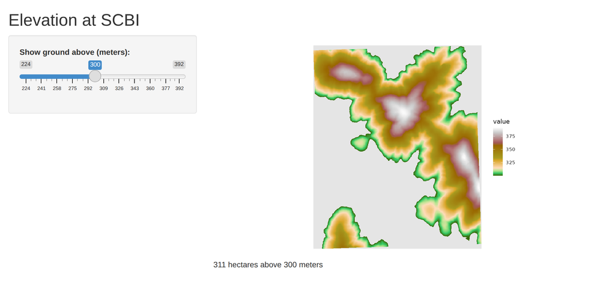

`glue::glue()` builds that sentence. Text inside `{}` is evaluated as R code and inserted into the string, so the sentence reports both the calculated area and the current value of `input$cutoff`. The `glue::` prefix makes the function available without attaching the *glue* package.

#### Reactive expressions

Both outputs now filter `dem` by the cutoff, and the filter runs twice whenever the slider moves.

An expression is **reactive** when its result depends on an input that can change. `reactive()` stores the result until a dependency changes, which allows several outputs to use the same calculation. We assign the reactive expression to `high_ground`:

```r
server <-
  function(
    input,
    output,
    session
  ) {
    high_ground <-
      reactive({
        dem %>%
          filter(elevation > input$cutoff)
      })

    output$map <-
      renderPlot({
        ggplot() +

          # Add geometries:

          geom_spatraster(data = high_ground()) +

          # Define scale elements:

          scale_fill_hypso_c(na.value = "grey90") +

          # Modify the theme:

          theme_void()
      })

    output$area <-
      renderText({
        hectares <-
          cell_area %>%
          terra::mask(high_ground()) %>%
          terra::global("sum", na.rm = TRUE) %>%
          pull(sum) %>%
          round(1)

        glue::glue("{hectares} hectares above {input$cutoff} meters")
      })
  }
```

`high_ground` is a reactive expression, so we call it as `high_ground()` to return the filtered raster. When `input$cutoff` changes, the stored result becomes invalid. The next output that calls `high_ground()` triggers the calculation with the new cutoff.

Using `reactive()` rather than repeating the calculation provides two advantages:

**The filtered raster is calculated once per change, not twice.** Both `output$map` and `output$area` call `high_ground()`, and Shiny caches the value until `input$cutoff` changes.

**A change invalidates only the expressions that depend on that input.** A control that changes the map’s colors does not require another elevation filter unless the filtering expression also refers to that control.

The app looks and behaves exactly as it did before we made the change, which is the point. `shinyApp(ui, server)` is still the last line of the file, and it now runs a complete interface and a complete server.

Read your data outside the server!

Reading, projecting, or resampling inside a reactive or rendering expression makes the app repeat that work whenever a dependent input changes. A projection that takes two seconds makes the app respond slowly.

I recommend organizing the app by when each operation needs to run:

- At the top of the file, outside `ui` and `server`: read the files, project them, align their grids, and do anything else that does not depend on an input. This runs once.
- Inside `reactive()`: only what actually depends on an input.
- Inside `render*()`: construct the plot, text, table, or other result returned to the interface.

When preprocessing is slow, we can do it in a separate script and use `writeRaster()` to save the processed raster. The app can then read the finished file at the top of the script.

What `session` is for, and why a reactive is lazy

The server function also includes `session`, and reactive expressions use lazy evaluation.

**`session` is the third argument and this app never uses it.** It represents the current user’s connection. Functions that update a control from the server or run code when a connection closes use this object. We include it here because students will commonly encounter the full three-argument server function.

**A reactive is lazy as well as cached.** Shiny does not immediately recalculate `high_ground()` when the slider moves. It marks the stored result as invalid and calculates a new result the next time an output uses it. Shiny records the inputs used while evaluating the expression and uses those relationships to determine when the result becomes invalid.

Check your understanding

An app’s server reads `input$year` inside a `reactive()`. When does that expression re-evaluate?

After input$year changes, when an output next requests its value Every time any input changes Once, when the app starts Every second, until the app is closed

True or false: A `SpatRaster` read at the top of an app file is re-read each time an input changes.

Now you!

Add a checkbox that lets the reader decide whether the ground below the selected elevation is drawn in grey or left transparent.

*Hint: `checkboxInput()` takes an `inputId`, a `label`, and a starting `value`. The server reads the value as `input$show_excluded`.*

Click here to see my answer

In the interface, beneath the slider:

```r
checkboxInput(
  inputId = "show_excluded",
  label = "Shade ground below the cutoff",
  value = TRUE
)
```

Then use that value in `renderPlot()`:

```r
output$map <-
  renderPlot({
    excluded_color <-
      if_else(
        input$show_excluded,
        "grey90",
        NA_character_
      )

    ggplot() +

      # Add geometries:

      geom_spatraster(data = high_ground()) +

      # Define scale elements:

      scale_fill_hypso_c(na.value = excluded_color) +

      # Modify the theme:

      theme_void()
  })
```

The checkbox changes only how the missing cells are drawn, so the filtered raster does not need to be recalculated. `high_ground()` still depends only on `input$cutoff`.

## Running and deploying a Shiny application

*Run App* starts the app in an R session on your computer. Closing that session stops the app, and other users cannot access it.

To share the app, we must deploy it to a service that can run R and respond to users. This differs from publishing a rendered Quarto document, which produces files that can be served without an active R session. Common deployment options include:

- **shinyapps.io**, a service from Posit with a free tier. The *rsconnect* package deploys apps to the service. This is where the preliminary lessons of this course are hosted.
- **Posit Connect** or a self-hosted **Shiny Server**, which an institution can run.
- **shinylive**, which uses WebAssembly to run R and the app in the user’s browser. It can be hosted as static files, but only packages available for webR can be used.

The deployment must include the app’s data, and raster files can be large. An app that reads a 200 MB GeoTIFF will take longer to deploy and start. Aggregate the raster to the resolution required for the displayed map, save that version for the app, and retain the full-resolution file for the analysis.

## Putting it all together

The app works because each piece is placed according to when it should run and what it should return. My own model for that looks like this (click to expand):

[figure not shown]

**Note**

This workflow is a visualization of *my* mental model for these functions. It is totally okay if your model differs! What is important is that you have a *working* model, a system in place that allows you to retrieve the function or functions that you need to solve a problem.

## Take-home points

- A Shiny app includes a user interface, a server function, and a call to `shinyApp()`. The input and output names in the user interface must match those used in the server.
- Each input has an `inputId`. The server accesses its current value as `input$<id>`. A result assigned to `output$<id>` appears at the matching `plotOutput()` or `textOutput()` location in the user interface.
- Code at the top of the file runs once when the app starts, and the server function body runs once per browser session. Place startup work, such as reading a raster, at the top of the file. Complete slow preprocessing before the app starts whenever possible.
- `reactive()` defines an expression that Shiny can reuse. Shiny caches the result until a value used by the expression changes.
- `filter()` on a `SpatRaster` leaves the extent unchanged and sets cells that do not meet the condition to `NA`, which prevents the map from jumping as a control moves.
- Deploying an app means running R somewhere a reader can reach, through shinyapps.io, a server of your own, or shinylive. Include the required data, and aggregate a raster to the resolution used in the app.

## Exercises

Test your knowledge!

1. An app runs, the controls appear, and the plot panel is blank. What is the first thing to check?

That the name in plotOutput() matches the name assigned in output$ That the raster was read inside the server That shinyApp() was called before the server was defined That the slider's min and max cover the data

2. Why is `reactive()` preferable to repeating a calculation in two `render*()` blocks?

Its result is cached and reused by both render blocks until a dependency changes It runs the calculation before the app starts It is the only way for the server to read an input It prevents the outputs from redrawing

3. An app projects a large raster inside `renderPlot()` and responds too slowly to use. What is the best fix?

Project it during preprocessing, then read the processed raster at the top of the app file Move the projection into a reactive() so that it is cached Reduce the size of the plot Use renderImage() instead of renderPlot()

## Reference

- **Code section**: A portion of an R script file that is delineated by a section header.
- **Global environment**: A workspace that provides a reference point for all user-assigned objects associated with the current session.
- **Reactive**: Describes an expression that Shiny re-evaluates when something it reads has changed, and caches otherwise.
- **Server**: The half of a Shiny app that reads the values the interface produced, calculates whatever depends on them, and writes results back to the interface.
- **Session history**: All lines of code that have been sent to R since the beginning of a session (or since the session history was last cleared).
- **Shiny app**: A web page whose server is running R, so that a reader’s choices are answered by a calculation rather than by a stored result.
- **User interface**: The half of a Shiny app that describes what the reader sees, and that produces the values the server reads.
- **Workspace pane**: A pane of RStudio used to view/manage objects in your global environment and your session history.

**Important!** Primitive functions, as well as functions in the packages that R attaches by default (e.g., *base*, *utils*, *stats*, and *graphics*), are available as soon as you start an R session.

| Package | Function | Definition |
| --- | --- | --- |
| .Primitive | $ | Infix operator that extracts the values associated with a name (RHS) from a recursive object (LHS) |
| .Primitive | + | Infix arithmetic operator (addition) |
| .Primitive | / | Infix arithmetic operator (divide) |
| .Primitive | : | Infix operator that generates a regular sequence of adjacent values |
| .Primitive | :: | Infix operator that can be used to access a package environment without attaching the whole package environment to your current session |
| .Primitive | <- | Infix operator that assigns an object on the right-hand-side (RHS) to a name on the left-hand-side (LHS) -- this should be used for global assignments! |
| .Primitive | = | Infix operator that assigns an object on the right-hand-side (RHS) to a name on the left-hand-side (LHS) -- this should not be used for global assignments! |
| .Primitive | > | Infix relational operator (greater than) |
| .Primitive | function | The primitive used to define a custom function. |
| .Primitive | {...} | Operator that passes the last operation in `{...}` to the global environment |
| base | library | Attach the package environment for a given package to the current R session |
| base | round | Round a numeric value to a given number of decimal places. |
| dplyr | filter | Subset a data frame by logical condition |
| dplyr | if_else | Classify or reclassify a vector into two classes by applying a logical test and assigning one value if the test evaluates to `TRUE` and another if it evaluates to `FALSE` |
| dplyr | pull | Extract a column from a data frame as a vector |
| dplyr | rename | Change the name assigned to a column in a data frame |
| ggplot2 | ggplot | Set the data and, potentially, the aesthetics of a plot |
| ggplot2 | theme_void | A ggplot theme that contains no axes or panel background |
| magrittr | %>% | The pipe operator passes the output of the LHS argument to the function on the right |
| shiny | checkboxInput | A Shiny control returning TRUE or FALSE. |
| shiny | fluidPage | Build the page of a Shiny user interface. |
| shiny | mainPanel | The panel of a sidebar layout that holds the results. |
| shiny | plotOutput | Reserve a place in a Shiny interface for a plot the server will draw. |
| shiny | reactive | Hold an expression that Shiny re-evaluates when an input it reads has changed. |
| shiny | renderPlot | Assign a plot to an output of a Shiny app. |
| shiny | renderText | Assign text to an output of a Shiny app. |
| shiny | shinyApp | Join a user interface and a server function into an application, and run it. |
| shiny | sidebarLayout | Split a Shiny page into a panel of controls and a panel of results. |
| shiny | sidebarPanel | The panel of a sidebar layout that holds the controls. |
| shiny | sliderInput | A Shiny control returning a number chosen from a range. |
| shiny | textOutput | Reserve a place in a Shiny interface for text the server will write. |
| shiny | titlePanel | Add a title to a Shiny page. |
| terra | cellSize | Return the area of each cell of a raster, in a unit named by its unit = argument. |
| terra | global | Calculate a summary statistic across each cell in a raster |
| terra | mask | A type of join in which you convert all cells in a target raster to NA if they are outside of a source object (e.g., a polygon shapefile or SpatVector) |
| terra | project | Transform the CRS of a raster |
| terra | rast | Read in a raster object, create a raster object from scratch, or convert a list of raster objects to a raster stack |
| tidyterra | geom_spatraster | Draw a SpatRaster in a ggplot, mapping its first layer to fill unless another is named. |
| tidyterra | scale_fill_hypso_c | A continuous fill scale using a hypsometric palette, the convention for elevation on a topographic map. |
| utils | install.packages | Download and install one or more packages onto your computer. |

The most common keyboard shortcuts are provided below for Windows and Mac operating systems.

| Task | Windows | Mac |
| --- | --- | --- |
| View all keyboard shortcuts | Alt + ⇧ + K | ⌥ + ⇧ + K |
| Open an existing script | Ctrl + O | ⌘ + O |
| Create a new script | Ctrl + ⇧ + N | ⌘ + ⇧ + N |
| Save script file | Ctrl + S | ⌘ + S |
| Execute code | Ctrl + Enter | ⌘ + Return |
| Copy | Ctrl + C | ⌘ + C |
| Paste | Ctrl + V | ⌘ + V |
| Add a pipe operator | Ctrl + ⇧ + M | ⌘ + ⇧ + M |
| Add an assignment operator | Alt + dash | ⌥ + dash |
| Add a new code section | Ctrl + ⇧ + R | ⌘ + ⇧ + R |
| Indent code | Ctrl + I | ⌘ + I |